# ggplot

Prof. Harbert

September 19, 2018

## ggplot

The ggplot library is part of the ‘tidyverse’. While not the only way to make great graphics in R, ggplot is the leading data visualization software in R.

More: https://ggplot2.tidyverse.org/

And a great cheat-sheet: https://github.com/rstudio/cheatsheets/blob/master/data-visualization-2.1.pdf

```r
# install.packages("tidyverse") # if not yet installed

library(tidyverse)
demo <- read.delim("https://raw.githubusercontent.com/rsh249/bioinformatics/master/data/demo.tab")

# examine
head(demo) # view the first 6 rows
```

```
##   gp   sub y x
## 1  a   red 1 1
## 2  a green 1 2
## 3  a  blue 1 3
## 4  a   red 1 4
## 5  a green 1 5
## 6  a  blue 1 6
```

```r
head(demo, n = 10) # view the first n rows
```

```
##    gp   sub y  x
## 1   a   red 1  1
## 2   a green 1  2
## 3   a  blue 1  3
## 4   a   red 1  4
## 5   a green 1  5
## 6   a  blue 1  6
## 7   a   red 1  7
## 8   a green 1  8
## 9   a  blue 1  9
## 10  a   red 1 10
```

```r
str(demo) # describe the STRucture of the data.frame
```

```
## 'data.frame':    1200 obs. of  4 variables:
##  $ gp : Factor w/ 3 levels "a","b","c": 1 1 1 1 1 1 1 1 1 1 ...
##  $ sub: Factor w/ 3 levels "blue","green",..: 3 2 1 3 2 1 3 2 1 3 ...
##  $ y  : int  1 1 1 1 1 1 1 1 1 1 ...
##  $ x  : int  1 2 3 4 5 6 7 8 9 10 ...
```

```r
# generate summary statistics
summary(demo$x)
```

```
##    Min. 1st Qu.  Median    Mean 3rd Qu.    Max.
##     1.0   100.8   200.5   200.5   300.2   400.0
```

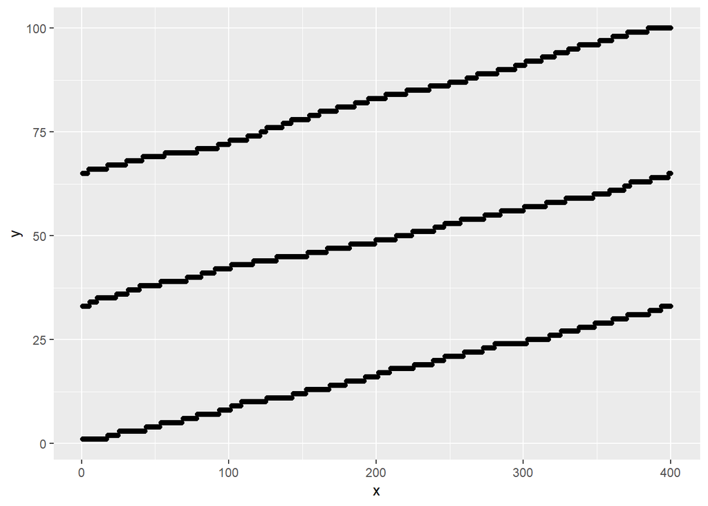

```r
# SCATTERPLOTS
ggplot(data = demo) +
  geom_point(mapping = aes(x = x, y = y))
```

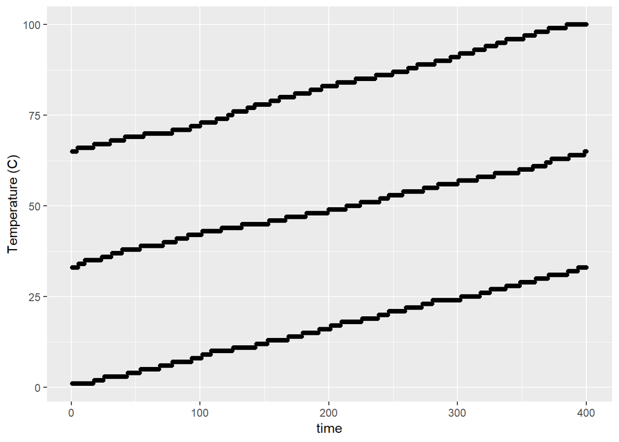

```r
# change x and y axis titles
ggplot(data = demo) +
  geom_point(mapping = aes(x = x, y = y)) +
  xlab("time") + ylab("Temperature (C)")
```

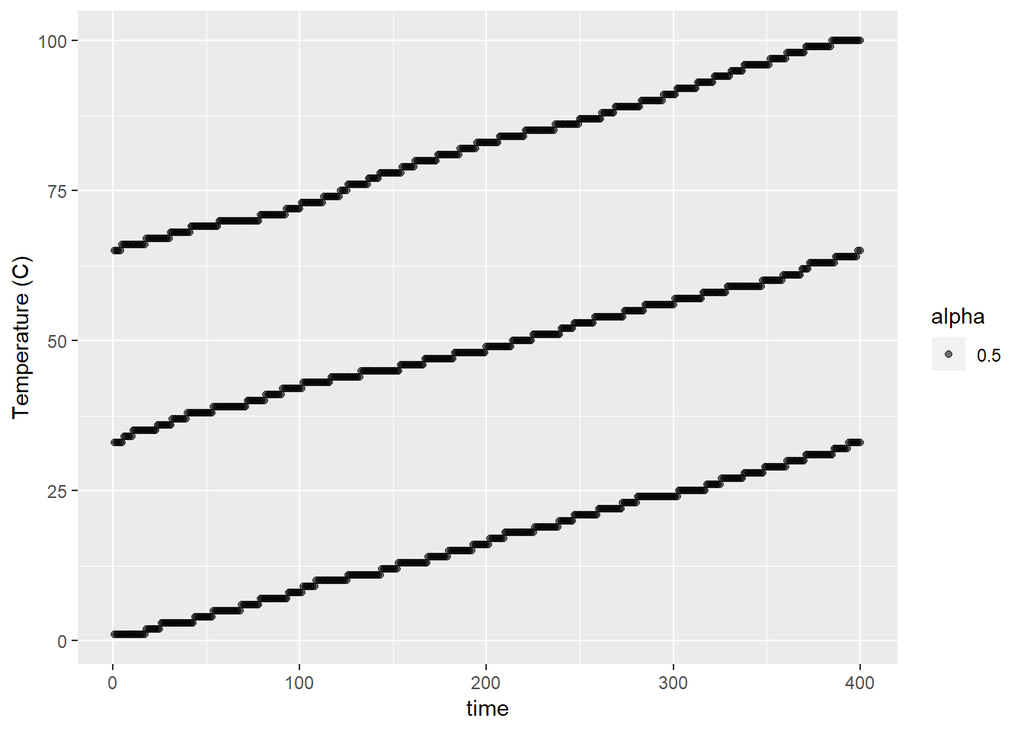

```r
# use transparency to better visualize clusters of points
# with the "alpha" parameter

ggplot(data = demo) +
  geom_point(mapping = aes(x = x, y = y,alpha =0.5)) +
  xlab("time") + ylab("Temperature (C)")
```

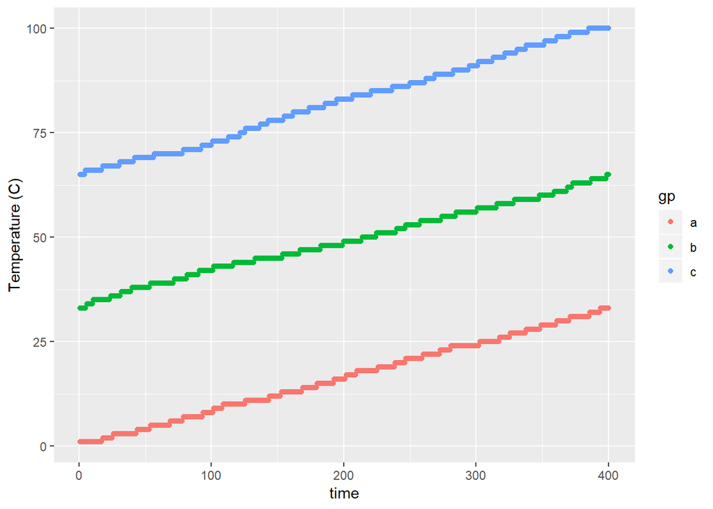

```r
#or color by a group column
ggplot(data = demo) +
  geom_point(mapping = aes(x = x, y = y, col=gp)) +
  xlab("time") + ylab("Temperature (C)")
```

# Aesthetics:

Depending on the graphics you are building you can define the aes() function in the ggplot() function OR (as above) in the the geom function call:

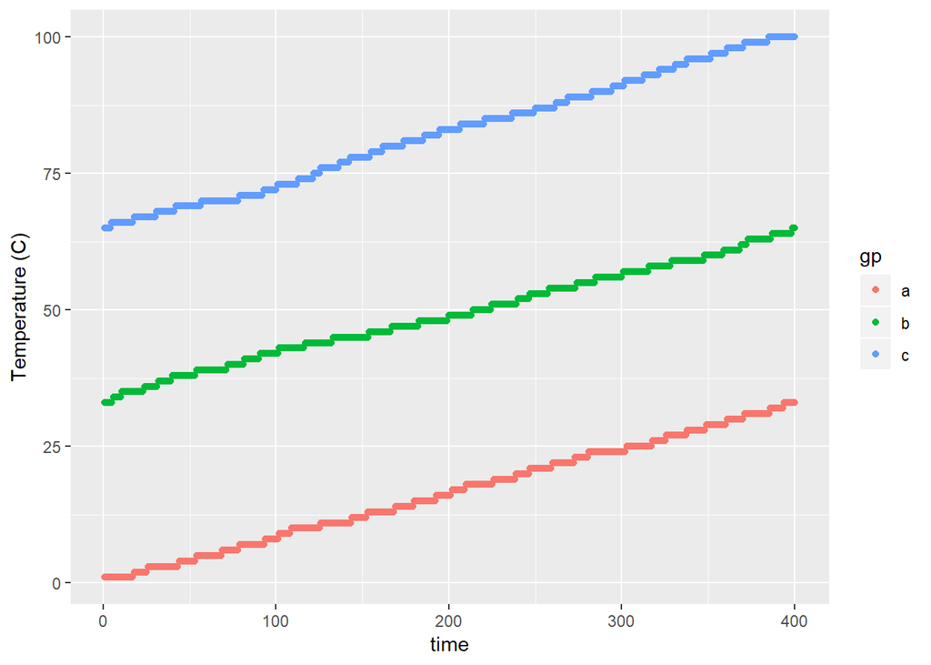

```r
ggplot(data = demo, aes(x=x, y=y, col=gp)) +
  geom_point() + xlab("time") + ylab("Temperature (C)")
```

# Saving plot objects:

You can save a basic plot object by assigning it to an R object:

```r
base = ggplot(data = demo, aes(x=x, y=y, col=gp)) +
  geom_point() + xlab("time") + ylab("Temperature (C)")
```

This object (‘base’ in this example) can then be reused and modified. We will cover several modifications below.

# Facetting – multiple plots

In ggplot the facet (facet_wrap, facet_grid) functions will make a multipanel plot with subplots sorted by a grouping factor.

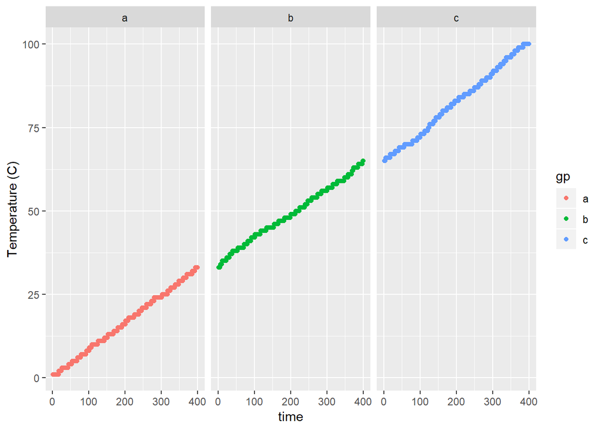

```r
base +
  facet_wrap(~ gp)
```

# Style, Colors, and Themes

The basic ggplot formatting is OK, but we can do better with a few stylistic tweaks.

## Themes

One of the easiest is to attach a theme function to the end of your ggplot call. These can be viewed with: ?theme_bw()

e.g., theme_bw()

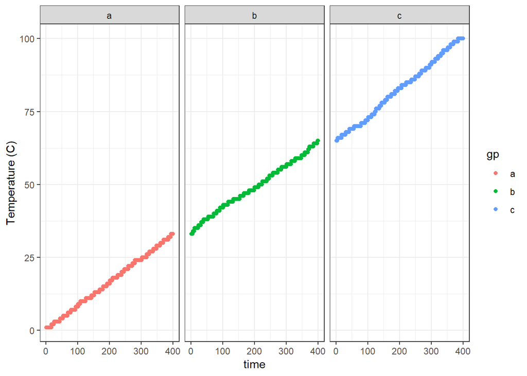

```r
base +
  facet_wrap(~ gp) +
  theme_bw()
```

e.g., theme_minimal()

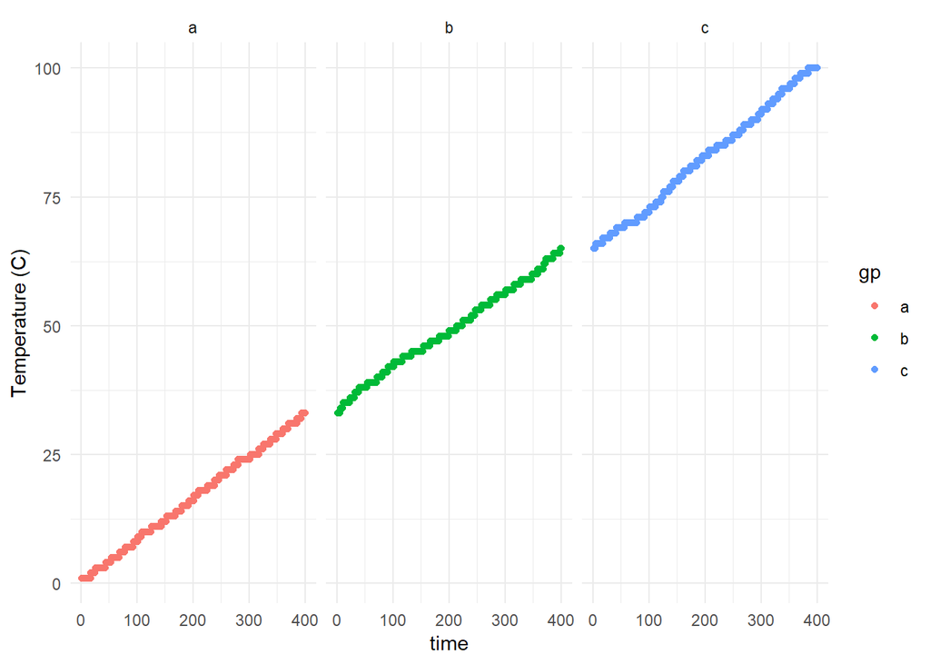

```r
base +
  facet_wrap(~ gp) +
  theme_minimal()
```

I like this version so I’m going to save it as another R object that keeps this formatting.

```r
minimal = base +
  facet_wrap(~ gp) +
  theme_minimal()
```